## Train-Test Split

In this section, the wine data set is splitted into training set and test set for applying machine learning algorithms later on. Here we use a 70% - 30% stratification. The dimension of training set is (4548, 13), and the dimension of test set is (1949, 13).

```
## [1] "Dimension of red wine data set: 4548, 13"
```

```
## [1] "Dimension of red wine data set: 1949, 13"
```

## Models Using all Predictors

In this section, we build machine learning models: logistic regression, LDA, QDA, tree model and random forest, based on all the potential predictors to predict whether the wine is red or not.

### logistic regression

```
## Confusion Matrix and Statistics
##
##           Reference
## Prediction    0    1
##          0 1466    5
##          1    3  475
##
##                Accuracy : 0.9959
##                  95% CI : (0.9919, 0.9982)
##     No Information Rate : 0.7537
##     P-Value [Acc > NIR] : <2e-16
##
##                   Kappa : 0.9889
##
##  Mcnemar's Test P-Value : 0.7237
##
##             Sensitivity : 0.9980
##             Specificity : 0.9896
##          Pos Pred Value : 0.9966
##          Neg Pred Value : 0.9937
##              Prevalence : 0.7537
##          Detection Rate : 0.7522
##    Detection Prevalence : 0.7547
##       Balanced Accuracy : 0.9938
##
##        'Positive' Class : 0
##
```

The logistic regression model has great performance. It has overall accuracy of 0.9959, with sensitivity and specificity 0.9980 and 0.9896, which is pretty high. This model performs very good in predicting white wine as well as in predicting red wine.

### LDA

```
## Confusion Matrix and Statistics
##
##           Reference
## Prediction    0    1
##          0 1468    5
##          1    1  475
##
##                Accuracy : 0.9969
##                  95% CI : (0.9933, 0.9989)
##     No Information Rate : 0.7537
##     P-Value [Acc > NIR] : <2e-16
##
##                   Kappa : 0.9917
##
##  Mcnemar's Test P-Value : 0.2207
##
##             Sensitivity : 0.9896
##             Specificity : 0.9993
##          Pos Pred Value : 0.9979
##          Neg Pred Value : 0.9966
##              Prevalence : 0.2463
##          Detection Rate : 0.2437
##    Detection Prevalence : 0.2442
##       Balanced Accuracy : 0.9945
##
##        'Positive' Class : 1
##
```

### QDA

For QDA model, since in this section the number of predictors is quite high, there is a problem of rank deficiency of red wine group of our training set, which means the parameters required by QDA model cannot be estimated from the data we currently have. Therefore, the QDA model is ignored in this section, but will be applied in following section.

### Tree Model

```
## Confusion Matrix and Statistics
##
##           Reference
## Prediction    0    1
##          0 1450   30
##          1   19  450
##
##                Accuracy : 0.9749
##                  95% CI : (0.9669, 0.9813)
##     No Information Rate : 0.7537
##     P-Value [Acc > NIR] : <2e-16
##
##                   Kappa : 0.9318
##
##  Mcnemar's Test P-Value : 0.1531
##
##             Sensitivity : 0.9375
##             Specificity : 0.9871
##          Pos Pred Value : 0.9595
##          Neg Pred Value : 0.9797
##              Prevalence : 0.2463
##          Detection Rate : 0.2309
##    Detection Prevalence : 0.2406
##       Balanced Accuracy : 0.9623
##
##        'Positive' Class : 1
##
```

The tree model here has lower accuracy compared to LDA or logistic regression model, with much lower sensitivity, which means it doesn’t perform very well in predicting red wine.

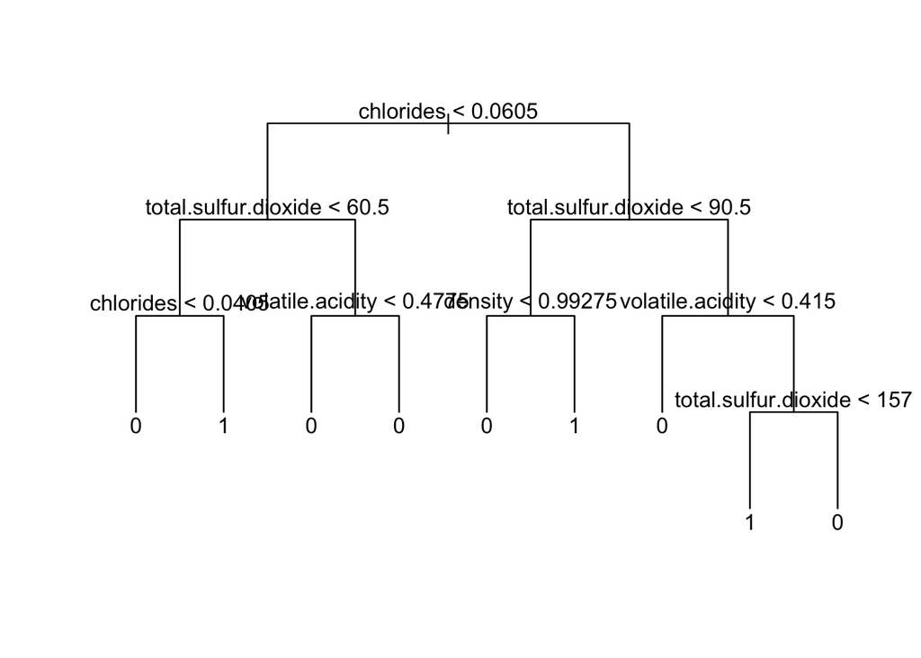

### Random Forest

```
## Confusion Matrix and Statistics
##
##           Reference
## Prediction    0    1
##          0 1467    9
##          1    2  471
##
##                Accuracy : 0.9944
##                  95% CI : (0.9899, 0.9972)
##     No Information Rate : 0.7537
##     P-Value [Acc > NIR] : < 2e-16
##
##                   Kappa : 0.9847
##
##  Mcnemar's Test P-Value : 0.07044
##
##             Sensitivity : 0.9812
##             Specificity : 0.9986
##          Pos Pred Value : 0.9958
##          Neg Pred Value : 0.9939
##              Prevalence : 0.2463
##          Detection Rate : 0.2417
##    Detection Prevalence : 0.2427
##       Balanced Accuracy : 0.9899
##
##        'Positive' Class : 1
##
```

The random forest model has high overall accuracy, high sensitivity, high specificity as well.

| feature | Gini |
| --- | --- |
| chlorides | 495.285824 |
| total.sulfur.dioxide | 479.779746 |
| volatile.acidity | 213.935961 |
| density | 92.226194 |
| sulphates | 88.814961 |
| fixed.acidity | 79.537298 |
| residual.sugar | 74.342893 |
| free.sulfur.dioxide | 72.788205 |
| citric.acid | 33.838574 |
| pH | 33.304306 |
| alcohol | 16.991101 |
| quality | 5.782033 |

This table shows that **chlorides** and **total sulfur dioxide** are the two most important predictors in classifying red wine and white wine.

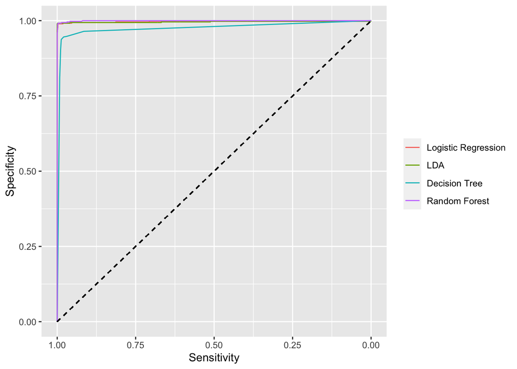

```
## [1] "For logistic regression model, the AUC is 0.996756580440209"
```

```
## [1] "For LDA model, the AUC is 0.996124063989108"
```

```
## [1] "For tree model, the AUC is 0.97505034604039"
```

```
## [1] "For random forest model, the AUC is 0.999619922850011"
```

The ROC curves and AUC all indicate that these models perform very good in predicting whether a wine is red or not. The model that has the highest AUC is the random forest model.